# An Ensemble Model to Predict the Likelihood of Stroke: Development and Evaluation

Forsythe, Sara

Fall 2025

## Load Libraries

The libraries used for this project are `reticulate`, `tidyverse`, `psych`, `randomForest`, `caret`, `glmnet`, `xgboost` and `pROC`. Data is downloaded from Kaggle and saved in a dataframe.

## Background

Stroke is the world’s second leading cause of death and a major driver of long-term disability. It is a neurological disorder caused by the blockage of blood vessels. Stroke occurrence increases with age. Strokes are more common in younger women than younger men and in women have been associated with pregnancy, contraceptive use and hormonal therapy. In men strokes have been associated with smoking, alcohol consumption, myocardial infarction and arterial disorders. Strokes have also been associated with air pollution, hypertension, atrial fibrillation and diabetes mellitus (Kuriakose & Xiao, 2020).

Given that stroke is a leading cause of death, the ability to predict a stroke before it occurs could provide patients and clinicians valuable time to take preventive action. This dataset contains easily collected patient information and will be used to develop predictive models to identify individuals at risk of experiencing a stroke.

## Data Exploration

```
The initial data set structure:
'data.frame':   5110 obs. of  12 variables:
 $ id               : int  9046 51676 31112 60182 1665 56669 53882 10434 27419 60491 ...
 $ gender           : Factor w/ 3 levels "Female","Male",..: 2 1 2 1 1 2 2 1 1 1 ...
 $ age              : num  67 61 80 49 79 81 74 69 59 78 ...
 $ hypertension     : int  0 0 0 0 1 0 1 0 0 0 ...
 $ heart_disease    : int  1 0 1 0 0 0 1 0 0 0 ...
 $ ever_married     : Factor w/ 2 levels "No","Yes": 2 2 2 2 2 2 2 1 2 2 ...
 $ work_type        : Factor w/ 5 levels "children","Govt_job",..: 4 5 4 4 5 4 4 4 4 4 ...
 $ Residence_type   : Factor w/ 2 levels "Rural","Urban": 2 1 1 2 1 2 1 2 1 2 ...
 $ avg_glucose_level: num  229 202 106 171 174 ...
 $ bmi              : num  36.6 NA 32.5 34.4 24 29 27.4 22.8 NA 24.2 ...
 $ smoking_status   : Factor w/ 4 levels "formerly smoked",..: 1 2 2 3 2 1 2 2 4 4 ...
 $ stroke           : int  1 1 1 1 1 1 1 1 1 1 ...
```

```
The initial data set summary:
       id           gender          age         hypertension
 Min.   :   67   Female:2994   Min.   : 0.08   Min.   :0.00000
 1st Qu.:17741   Male  :2115   1st Qu.:25.00   1st Qu.:0.00000
 Median :36932   Other :   1   Median :45.00   Median :0.00000
 Mean   :36518                 Mean   :43.23   Mean   :0.09746
 3rd Qu.:54682                 3rd Qu.:61.00   3rd Qu.:0.00000
 Max.   :72940                 Max.   :82.00   Max.   :1.00000

 heart_disease     ever_married         work_type    Residence_type
 Min.   :0.00000   No :1757     children     : 687   Rural:2514
 1st Qu.:0.00000   Yes:3353     Govt_job     : 657   Urban:2596
 Median :0.00000                Never_worked :  22
 Mean   :0.05401                Private      :2925
 3rd Qu.:0.00000                Self-employed: 819
 Max.   :1.00000

 avg_glucose_level      bmi                smoking_status     stroke
 Min.   : 55.12    Min.   :10.30   formerly smoked: 885   Min.   :0.00000
 1st Qu.: 77.25    1st Qu.:23.50   never smoked   :1892   1st Qu.:0.00000
 Median : 91.89    Median :28.10   smokes         : 789   Median :0.00000
 Mean   :106.15    Mean   :28.89   Unknown        :1544   Mean   :0.04873
 3rd Qu.:114.09    3rd Qu.:33.10                          3rd Qu.:0.00000
 Max.   :271.74    Max.   :97.60                          Max.   :1.00000
                   NA's   :201
```

There are 5110 rows and 12 columns. Gender has 1 patient in the other category. Having only 1 patient in a category will not work for modeling because it will only appear in the training or testing set. In the training set it can cause over fitting and in the testing set it can break the model if one-hot encoding was used. Replicating it and putting in both the training and testing set would add noise. I will convert other into NA and then impute using mode since it will be the only missing value. BMI has some abnormal values. 10.3 is very low and 97.6 is very high. The lowest reported BMI ever recorded was 6.7 (Suszko et al. 2022) and the highest BMI ever recorded was 204 (Terkawi et al. 2014). I will keep these values.

```
The features sorted by class:
$factor
[1] "gender"         "ever_married"   "work_type"      "Residence_type"
[5] "smoking_status"

$integer
[1] "id"            "hypertension"  "heart_disease" "stroke"

$numeric
[1] "age"               "avg_glucose_level" "bmi"
```

Hypertension and heart_disease are binary variables and not numeric. I will convert them to factors for my data exploration but convert them back to numeric for modeling since that will work better for logistic regression and xgboost. ID is a unique identifier and will be removed. It does not provide any predictive information. It can cause data leakage because the model might memorize the number rather than learning actual patterns. The outcome variable stroke needs to be converted to a factor.

```
Stroke:

   0    1
4861  249
```

The outcome variable stroke: 1 if the patient had a stroke or 0 if not, is very imbalanced. Only 4.9% of the patients had a stroke. This will need to be accounted for when modeling using class weights or SMOTE.

```
Count of NA values in each column:
           gender               age      hypertension     heart_disease
                0                 0                 0                 0
     ever_married         work_type    Residence_type avg_glucose_level
                0                 0                 0                 0
              bmi    smoking_status            stroke
              201                 0                 0
```

The following columns have NA values: bmi.

### Impute BMI

| method | MAE | RMSE |
| --- | --- | --- |
| Linear Model | 5.057200 | 6.696707 |
| Random Forest | 5.084195 | 6.703758 |
| Median | 5.779430 | 7.643286 |

Comparing three imputation strategies to impute BMI, median, linear regression and random forest, linear regression performed the best. It has the lowest MAE of 5.057 and lowest RMSE of 6.697. This suggests that the relationship between predictors and BMI in this dataset is approximately linear and I will use the linear model to impute BMI.

```
Summary of BMI after imputation using linear regression:
   Min. 1st Qu.  Median    Mean 3rd Qu.    Max.
  10.30   23.70   28.30   28.94   32.94   97.60
```

### Visualize Variables

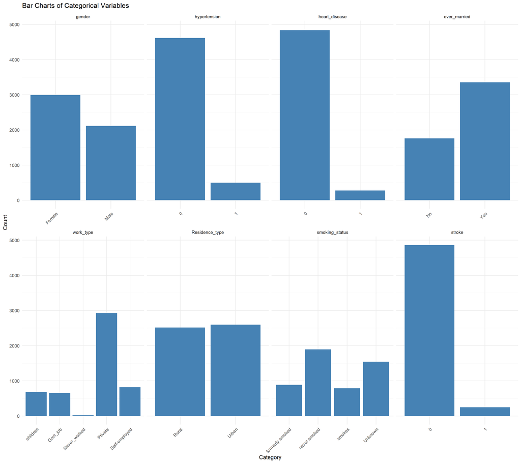

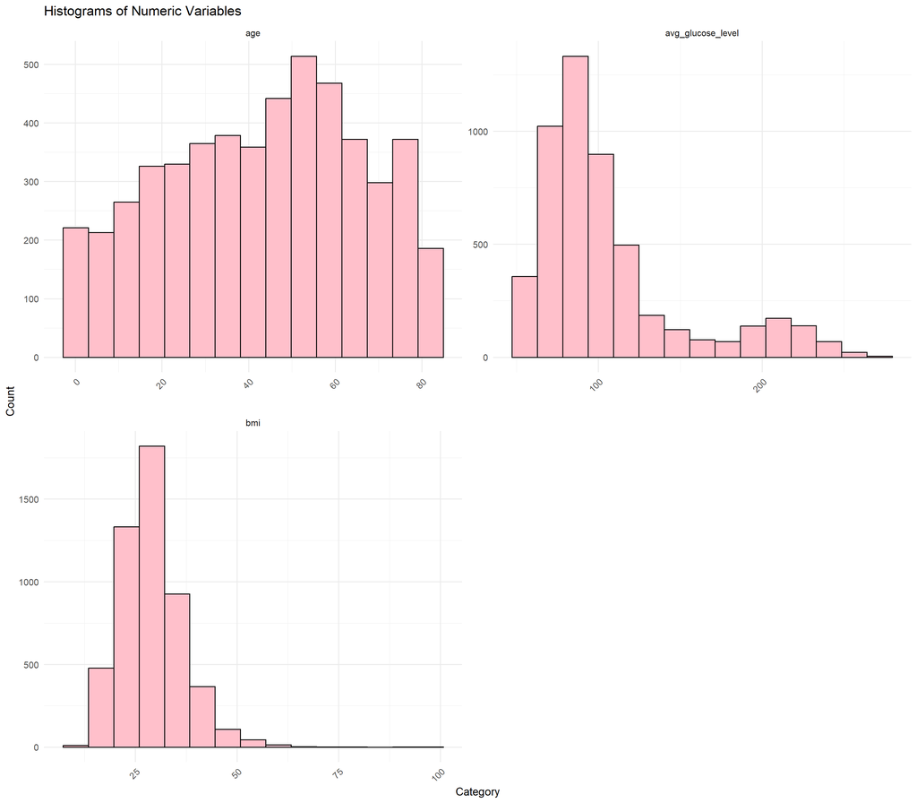

Both avg_glucose_level and bmi are right skewed and age also does not appear normally distributed.

Using the Shapiro-Wilk test the p-value of age is 1.88e-32. The p-value of avg_glucose_level is 5.13e-61. The p-value of bmi is 6.07e-37. The p-values are statistically significant meaning the data is not normal. It will be beneficial to log transform these variables for logistic regression.

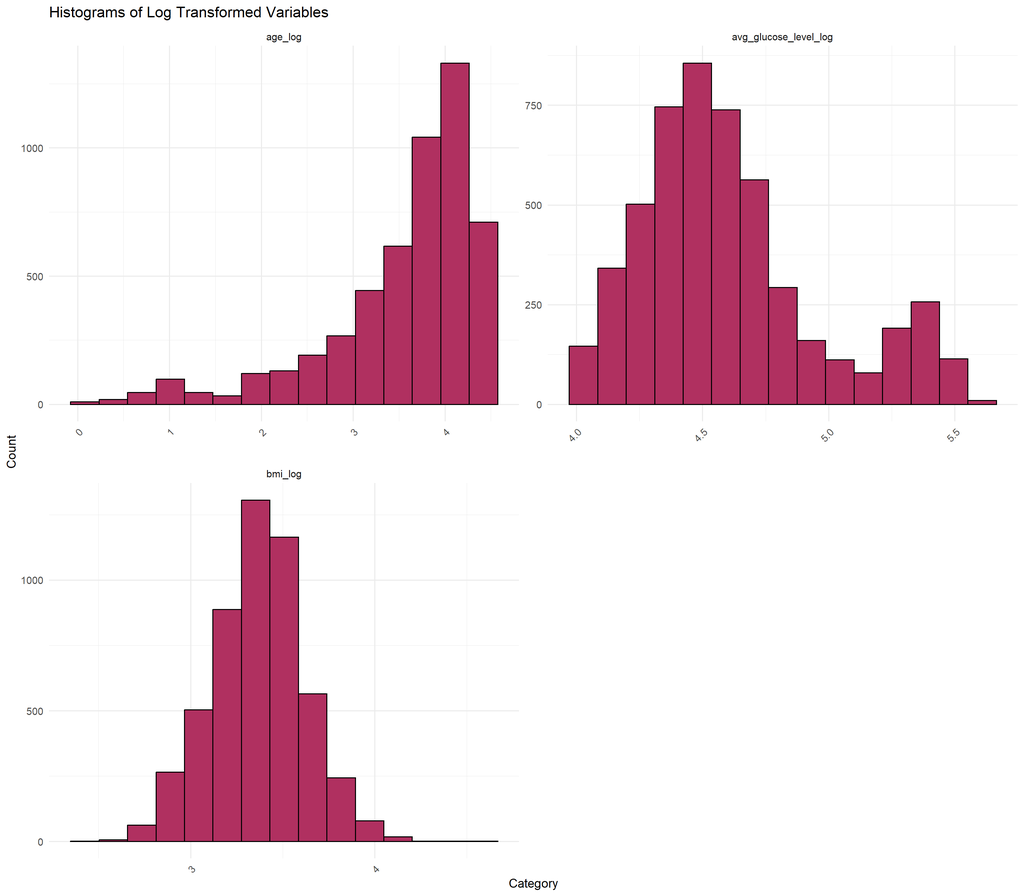

After log transformation, age became left-skewed, and average glucose level shows a secondary small peak, indicating the transformation reduced but did not eliminate non-normality. BMI, however, becomes noticeably closer to a normal distribution.

Even though perfect normality is not required for logistic regression, applying log transformations and scaling the predictors to a comparable range is still beneficial. These steps help to stabilize variance, reduce the influence of extreme values, improve algorithmic convergence, and make the penalization in glmnet behave more predictably across features.

Thus, scaling and transforming the numeric variables is appropriate and advantageous even if normality is not fully achieved.

### Test for multicollinearity

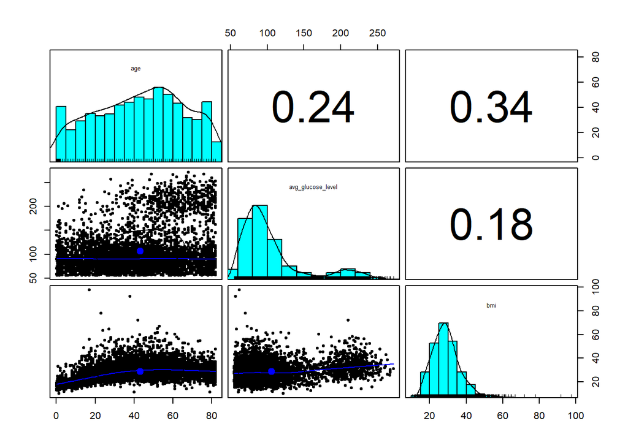

There is no strong pairwise correlations between the numeric variables.

I will recode stroke from 0/1 to No/Yes. This is because caret models need valid R names in the predictor class levels.

```
Summary of final data frame to be used for modeling:
    gender          age         hypertension     heart_disease     ever_married
 Female:2995   Min.   : 0.08   Min.   :0.00000   Min.   :0.00000   No :1757
 Male  :2115   1st Qu.:25.00   1st Qu.:0.00000   1st Qu.:0.00000   Yes:3353
               Median :45.00   Median :0.00000   Median :0.00000
               Mean   :43.23   Mean   :0.09746   Mean   :0.05401
               3rd Qu.:61.00   3rd Qu.:0.00000   3rd Qu.:0.00000
               Max.   :82.00   Max.   :1.00000   Max.   :1.00000
         work_type    Residence_type avg_glucose_level      bmi
 children     : 687   Rural:2514     Min.   : 55.12    Min.   :10.30
 Govt_job     : 657   Urban:2596     1st Qu.: 77.25    1st Qu.:23.70
 Never_worked :  22                  Median : 91.89    Median :28.30
 Private      :2925                  Mean   :106.15    Mean   :28.94
 Self-employed: 819                  3rd Qu.:114.09    3rd Qu.:32.94
                                     Max.   :271.74    Max.   :97.60
         smoking_status stroke        age_log        avg_glucose_level_log
 formerly smoked: 885   NO :4861   Min.   :0.07696   Min.   :4.027
 never smoked   :1892   YES: 249   1st Qu.:3.25810   1st Qu.:4.360
 smokes         : 789              Median :3.82864   Median :4.531
 Unknown        :1544              Mean   :3.55935   Mean   :4.603
                                   3rd Qu.:4.12713   3rd Qu.:4.746
                                   Max.   :4.41884   Max.   :5.609
    bmi_log
 Min.   :2.425
 1st Qu.:3.207
 Median :3.378
 Mean   :3.367
 3rd Qu.:3.525
 Max.   :4.591
```

### PCA

```
Importance of components:
                          PC1    PC2    PC3    PC4    PC5
Standard deviation     1.3456 0.9824 0.9101 0.9036 0.7614
Proportion of Variance 0.3621 0.1930 0.1656 0.1633 0.1160
Cumulative Proportion  0.3621 0.5551 0.7208 0.8840 1.0000
```

```
Variable loadings:
                     PC1    PC2    PC3    PC4    PC5
age               -0.567 -0.009  0.039 -0.319 -0.758
avg_glucose_level -0.426  0.106  0.361  0.823 -0.011
bmi               -0.440 -0.558  0.390 -0.320  0.490
hypertension      -0.426 -0.177 -0.846  0.176  0.203
heart_disease     -0.350  0.804  0.037 -0.296  0.378
```

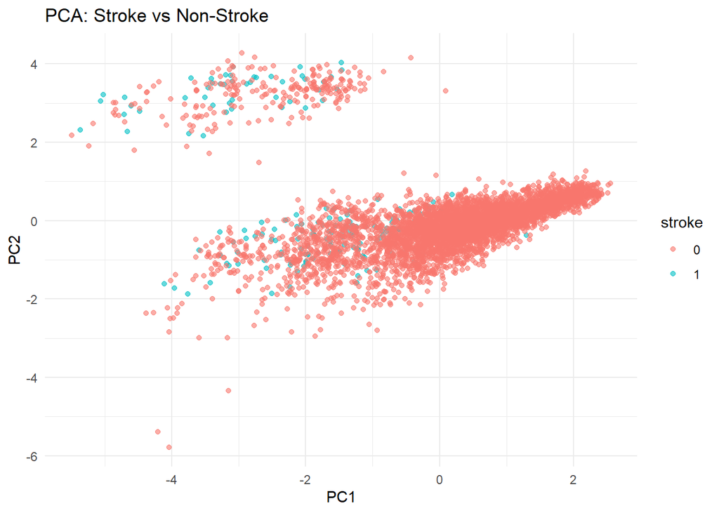

The PCA scatter plot (PC1 vs PC2) shows substantial overlap between stroke and non-stroke cases. There is no clear visual separation between classes, indicating that the primary directions of variance in the data are not driven by stroke outcomes. This aligns with the difficulty of this classification task and explains why linear models such as logistic regression struggle. The PCA results also highlight the need for nonlinear methods such as Random Forest and XGBoost, which can model complex interactions beyond what linear projections like PCA reveal.

Given that this dataset is fairly small with relatively few features. I will keep all the features for modeling and not perform feature selection.

## Create models

I will create three models. Random forest, xgboost and glm since they all can perform classification and handle numeric and categorical variables. These models are fairly interpretable which is important in healthcare. I will then combine the models into a heterogeneous ensemble using stacking.

### Split data

I will perform a two-stage split to create three mutually exclusive sets: Training, Validation, and Test. I will reserve 20% of the full dataset as a pure hold-out test set. This test set is never touched during training, tuning, or model selection which ensures the final evaluation is unbiased and reflects real-world performance. The second split splits the data into train and validation sets. The training set (64% of total data) is used to fit models. The validation set (16% of total data) is used for hyperparameter tuning, threshold search for best F1 and stacking meta-learner training. A combination of train and validation will be used for out of fold predictions to stack the models into a heterogeneous ensemble. This ensures that all tuning decisions are validated on data that the model has not seen during training and that there is no data leakage from the test set into model selection.

```
Orginal Data Frame:

        NO        YES
0.95127202 0.04872798
Training:

        NO        YES
0.95110024 0.04889976
Validation:

        NO        YES
0.95104039 0.04895961
Testing:

        NO        YES
0.95200784 0.04799216
```

I will use F1 scores to tune the model thresholds since it will balance the precision and recall given the dataset’s class imbalance. I will evaluate the fit of the algorithms using AUC-ROC. The classes are very imbalanced and AUC will tell me how well the model separates the classes despite the imbalance.

### Functions for building models

These functions are used when training the models. `add_obs_weights()` is a helper function to attach observations weights. This will be used for GLM models. `find_outlier_ids()` is a function that identifies outliers in numeric columns and returns row ids. This will be used for the GLM models. `f1_binary()` is a function that calculates F1 score. `pred_from_prob()` is a function that converts predicted probabilities into class predictions based on a chosen threshold. `f1_at_threshold()` is a helper function to determine the F1 score used in best_threshold. `best_threshold()` is function the finds the best threshold to maximize F1. `f1_summary()` is a function so F1 is used internally in model evaluation. `auc_binary()` is a function to calculate AUC from probabilities. `f1_auc_summary()` is a function that summarizes for caret F1 and AUC. `make_xgb_matrix()` is a function that takes a data frame and makes a matrix to pass to xgboost. It will ensure all matrices have the same columns. This will be used to create the training, validation and testing sets for XGBoost. `tune_meta_glmnet_F1()`is a function to optimize F1 for the glmnet meta-learner.

### Prepare data sets for training

Row_id will be dropped for all models before the dataframe is used in the model. GLM will use log transformed numeric columns and drop the plain numeric columns. Random forest and XGBoost will use drop the log transformed columns and keep the numeric columns.

### Train glmnet

I will train a bagged GLM model. This means its an ensemble of multiple elastic-net logistic regression models, each trained on a different bootstrap sample of the training data. I created two functions. `train_bag_glmnet()` is a function that creates bagged logistic regression model using glmnet with a alpha of 0.5. Elastic net regression should work best with an imbalanced outcome variable. It will tune for lambda with a default grid unless otherwise specified. `predict_bag_glmnet()` is a function to predict bagged glmnet. It takes a bagged model and data frame for predictions and can take a custom threshold.

```r
bag_glm_final <- train_bag_glmnet(
  df = glm_train_clean,
  weights_vec = weights_glm,
  B = 10,
  alpha = 0.5
)
```

### Train Random Forest

I will use balanced random forest because the data is imbalanced. It uses undersampling on the majority class to balance the dataset for each tree. I created a function `pretune_rf_F1()`. It pretunes random forest for F1 using k-fold cross validation. It uses a balanced random forest.

```r
rf_mod_final <- randomForest(
  x = rf_train[, keep_cols_rf_feats, drop = FALSE],
  y = rf_train[[target]],
  ntree = rf_best$ntree,
  mtry  = rf_best$mtry,
  sampsize = sampsize_vec
)
```

For random forest the best mtry - the hyperparameter that tells random forest how many random variables to use for each split - is 3. The best ntree - the number of tree grown for random forest - is 1000.

### Train XGBoost

Extreme Gradient Boosting (XGBoost) is a high-performance implementation of gradient-boosted decision trees. It builds a sequence of decision trees. Each new tree tries to correct the residual errors of the previous trees.

```r
xgb_grid <- expand.grid(
  nrounds = c(100, 200), # number of boosting iterations
  max_depth = c(3, 5), # depth of each tree
  eta = c(0.05, 0.1), # learning rate (shrinkage)
  gamma = 0, # minimum loss reduction for splitting
  colsample_bytree = 0.8, # feature subsampling
  min_child_weight = 1, # minimum lead node Hessian
  subsample = 0.8 # row subsampling
)

set.seed(130)
# This uses caret to build the xgboost model. Caret uses ntree_limit internally.
# However it was deprecated so it produces a warning. I wrapped it to silence
# the warnings
invisible(capture.output({
    xgb_fit <- train(
        x = xgb_train,
        y = xgb_train_y,
        method = "xgbTree",
        trControl = ctrl_F1_auc,
        tuneGrid = xgb_grid,
        metric = "F1",                   # TUNE on F1
        weights = cw_vec[as.character(xgb_train_y)]
        )
    }))

xgb_fit$bestTune
```

|  | nrounds | max_depth | eta | gamma | colsample_bytree | min_child_weight | subsample |
| --- | --- | --- | --- | --- | --- | --- | --- |
| 1 | 100 | 3 | 0.05 | 0 | 0.8 | 1 | 0.8 |

### Ensemble tuning

Tune the models on the validation set to find the best threshold for each model.

```r
# GLM validation prediction
val_prob_glm <- predict_bag_glmnet(bag_glm_final, glm_val, type = "prob")

# RF prediction
val_prob_rf  <- predict(rf_mod_final, rf_val, type = "prob")[, "YES"]

# XGB prediction
val_prob_xgb <- predict(xgb_fit, xgb_val, type = "prob")[, "YES"]
```

The best threshold for glmnet is (0.545) with a F1 of (0.4). This means glmnet is reasonably calibrated. The best threshold for random forest is (0.64) with a F1 of (0.35). This makes sense since a balanced random forest inflates the positive variable “YES”. The best threshold for XGBoost is (0.737) with a F1 of (0.34). This makes sense since XGBoost is often over confident and often predicts yes leading to many false positives, so it needs the highest threshold.

The AUC of glmnet on the validation set is (0.879). The AUC of random forest on the validation set is (0.877). The AUC of XGBoost on the validation set is (0.862).

### Heterogenous Ensemble

I will build a heterogeneous ensemble using out of fold stacking using the combined train and validation sets. Initially, I weighted the models based on their performance on the validation set. However, this resulted in weighting some models higher and then having them perform worse on the test set. Using out of fold probabilities will improve the ensemble weights because the validation signal is averaged across folds. I will stack the models using logistic regression - ridge penalty. This will encourage a blend of all models, so one model isn’t completely favored. This will be done in a for loop using 5-fold stratified cross validation.

```
4 x 1 sparse Matrix of class "dgCMatrix"
            s=0.006723358
(Intercept)     -5.765658
glm              3.291075
rf               1.241205
xgb              1.850930
```

GLM is the largest positive coefficient so the meta-learner is trusting it the most, then XGBoost and finally random forest.

The best threshold for the stacked heterogeneous ensemble is (0.13). The F1 of the heterogeneous ensemble is (0.279).

## Predict and evaluate final models

### Predictions on Base Models

```r
# Base-model probabilities
test_prob_glm <- predict_bag_glmnet(bag_glm_final, test_glm_data, type = "prob")
test_prob_rf  <- predict(rf_mod_final, test_rf_data, type = "prob")[, "YES"]
test_prob_xgb <- predict(xgb_fit, xgb_test, type = "prob")[, "YES"]
# Get predictions for base models using individual thresholds from validation
test_pred_glm <- pred_from_prob(test_prob_glm, glm_best_thr$threshold,
                                pos = "YES", neg = "NO")
test_pred_rf  <- pred_from_prob(test_prob_rf,  rf_best_thr$threshold,
                                pos = "YES", neg = "NO")
test_pred_xgb <- pred_from_prob(test_prob_xgb, xgb_best_thr$threshold,
                                pos = "YES", neg = "NO")
```

The F1 of glmnet is (0.245) and the AUC is (0.855). The F1 of random forest is (0.28) and the AUC is (0.854). The F1 of XGBoost is (0.295) and the AUC is (0.865). Interestingly GLM performed best on the validation data and within the stacked model on the training and validation sets. However, it performs worst on the testing data. This likely means GLM was slightly over fit. XGBoost performed the best on the testing set.

### Predictions for Heterogenous Ensemble

```r
# get probabilities from stacked ensemble
test_prob_ensemble <- as.numeric(predict(meta_fit,
                                         newx = X_test_meta,
                                         s = meta_best_lambda,
                                         type = "response")
                                 )
# get predictions from stacked ensemble
test_pred_ensemble <- pred_from_prob(
    test_prob_ensemble,
    thr = meta_oof_thr,
    pos = "YES",
    neg = "NO"
    )
```

After optimizing the stacking meta-learner directly for F1, the stacked model achieved an AUC of (0.865) and an F1 score of (0.259) on the test set. XGBoost alone obtained the same AUC (0.865) but a slightly higher F1 score (0.295). The predicted probabilities from the stacked model and XGBoost are extremely similar, with a Spearman correlation of 0.9797, indicating that the ensemble has not substantially changed the overall ranking of observations.

This helps explain why the AUC values are effectively identical. AUC is a global, threshold-independent metric that depends only on the pairwise ranking of positive vs. negative cases across all possible thresholds. Unless the stacking layer meaningfully reorders many YES/NO pairs, AUC will not improve. In this setting, XGBoost has the strongest discrimination and highest variance among the base learners, so it dominates the global ordering. The meta-learner (a GLM) primarily shifts and rescales the probabilities in a way that can help around a particular decision threshold, but it does not dramatically change the rank ordering. The random forest contributes modestly but not enough to alter many pairwise rankings.

Given that the stacked model does not improve AUC and its F1 score is slightly lower than that of XGBoost alone, I would favor using XGBoost by itself for this dataset. XGBoost is simpler than the heterogeneous stack (single model vs. three base learners plus a meta-learner), while delivering essentially the same or better performance. This also makes interpretation easier, since I can focus on one model’s feature importance rather than disentangling contributions across an ensemble.

If I wanted to further explore ensembling, a possible next step would be to use a more flexible meta-learner such as XGBoost (or another tree-based model) in place of the GLM. That might capture nonlinear interactions between base-model predictions and yield better threshold-specific performance, but it would need careful cross-validation to avoid overfitting.

### Citations

1. fedesoriano. (2020). “Stroke Prediction Dataset.” (Version 1) [Data set]. Kaggle. https://www.kaggle.com/datasets/fedesoriano/stroke-prediction-dataset/data
2. Kuriakose, D., & Xiao, Z. (2020). Pathophysiology and Treatment of Stroke: Present Status and Future Perspectives. International Journal of Molecular Sciences, 21(20), 7609. https://doi.org/10.3390/ijms21207609
3. Suszko, M., Sobocki, J., & Imieliński, C. (2022). Mortality in extremely low BMI anorexia nervosa patients: Implications of gastrointestinal and endocrine system dysfunction. Psychiatria Polska, 56(1), 89–100. https://doi.org/10.12740/PP/126233
4. Terkawi, A. S., Rafiq, M., Algadaan, R., Ur Rehman, I., Doais, K. S., Durieux, M. E., & AlSohaibani, M. (2014). General anesthesia for the heaviest man in the world. Saudi Journal of Anaesthesia, 8(Suppl 1), S101–S104. https://doi.org/10.4103/1658-354X.144087